# Other classifiers

Day 17

## Boostrap methods for Decision Trees

- Last class we learned decision trees are very flexible but also very prone to overfitting
- The main issue is that decision tress exhibit a lot of **variance**
  - If we split the sample in half and then fit trees, the results may be quite different
- We can reduce this **variance** by taking averages of different samples
  - If \(n\) independent observatons \(Z_1,\dots,Z_n\) have a variance of \(\sigma^2\), the variance of the mean \(\bar{Z}\) is \(\sigma^2/n\)
- How do we create \(n\) diffferent samples from 1 dataset?
  - `Bootstrapping`: sampling from our data with replacement
  - If data is \(1,2,3,4\), one sample is \(1,1,3,4\), another is \(2,3,1,1\), etc.

## Bagging for Decision Trees

- Bagging is a one method for reducing the effect of overfitting
- Alternative to cross-validation (less computationally intensive)
1. Create a `bootstrap training set` by sampling with replacement
   - all other cases are “out-of-the bag” (`OOB`) test cases
2. for each training set: construct a (deep) decision tree
   - use tree to predict classification of `OOB` test cases
3. Repeat steps 1-2 \(B\) times
4. For all cases: “average” the `OOB` predictions for each case
   - for `OOB` runs: get classification rates
   - usually majority rule: prediction is the **most popular** bootstrapped class prediction

## Random Forest

- Improves bagging by reducing correlation between `bootstrapped` trees:
  - for each `bootstrapped training set`: at each tree node, randomly select \(m\) predictors and split (or not) just based on these variables
    - usually \(m \approx \sqrt{p}\)
- How does randomly selecting predictors reduce correlation between trees?
  - can reduce the “dominance” of some variables that would always show up at the top of tree
- Why does reducing correlation help?
  - probability fact: averages of correlated random variables have *higher* variance than averages of independent ones!
- Should we be worried about extra computing time from creating \(B\) trees?
  - Not if we can parallelize. Use cores or even several computers to calculate \(B\) trees simulataneously then combine results

## Random Forest

- R package `randomForest`:
  - `randomForest(formula, data, ntree, mtry)`
  - `ntree` gives the number of bootstrapped trees
  - `mtry` is the number of predictors to randomly select
  - `mtry=p` will give bagging results
  - Note: categorical predictors/response must be `factor` types
- Here we fit a random forest model to the larger default model

```r
> set.seed(7)
> loans_rforest <- randomForest(Default ~ Credit.amount + Duration.in.month+
+                                 Age.in.years + Credit.history + Purpose+
+                                 Present.employment.since,
+                       data=loans, ntree=200, mtry=3)
```

## Random Forest

- `ntree=200` trees were fit with `mtry=3` variables selected at each node
- `randomForest` default: `sampsize` uses a *with replacement* sample size of `n` (size of the data)
  - when `n` is large, each case has about a \(63.2\%\) chance of being in the training sample
- `oob.times` tells us how many times that observation was in the `oob` set

```r
> loans_rforest$oob.times[1:10]
 [1] 68 84 64 72 70 78 79 74 76 79
> mean(loans_rforest$oob.times)
[1] 73.739
```

- here: each case should be in the OOB set in about \(36.8\% \ (1-63.2\%)\) of trees, or about \(73.6\) of the \(200\) trees

## Random Forest: Variable Importance

- Variable Importance:
  - the \(B\) bootstrapped trees will not always identify the same variables as “important”
- One way to measure importance of variable \(X\) is average total Gini decreases:
  - for each tree: find all nodes that split using \(X\)
  - for each tree: measure how much the Gini coefficient is decreased for this split
  - sum these decreases over all splits and trees
  - divide the total Gini decrease due to \(X\) by \(B\)

## Random Forest: Variable Importance

- Luckily there is a command that calculates this for us

```r
> importance(loans_rforest)
                         MeanDecreaseGini
Credit.amount                   131.72569
Duration.in.month                66.26430
Age.in.years                     92.59350
Credit.history                   41.73004
Purpose                          46.46882
Present.employment.since         37.16490
```

- Credit amount has most influence on increasing node purity
- Employment status the least influence
- Caveat: We don’t know the *direction* of the influence

## Random Forest: Variable Importance

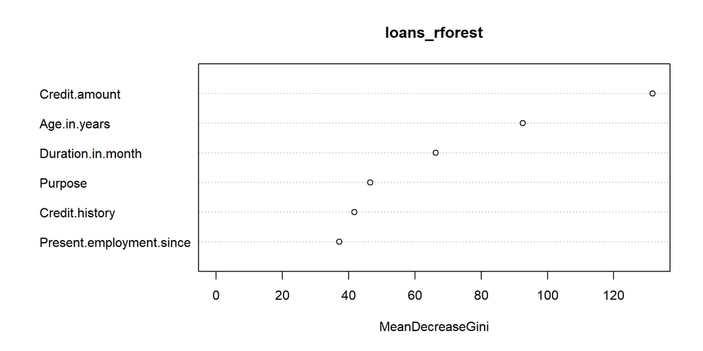

```r
> varImpPlot(loans_rforest)
```

## Random Forest: predictions/forecasts

- `predict(rf_object, type="prob")`: proportion of votes for `success`
- `predict(rf_object, type="response")`: vector of predictions (majority)

```r
> loans <- loans %>% mutate( probs = predict(loans_rforest, type="prob")[,2],
+               prediction = predict(loans_rforest, type="response")
+                   )
>   select(loans, Default, probs, prediction) %>% head()
    Default      probs prediction
1 NoDefault 0.04411765  NoDefault
2   Default 0.63095238    Default
3 NoDefault 0.01562500  NoDefault
4 NoDefault 0.40277778  NoDefault
5   Default 0.32857143  NoDefault
6 NoDefault 0.38461538  NoDefault
```

## Random Forests: predictions/forecasts for new data

- Use `newdata` command to predict out of sample (here I am using loans just as an example)

```r
> predict(loans_rforest, type="response", newdata=loans[900,])
    900
Default
Levels: NoDefault Default
> predict(loans_rforest, type="prob", newdata=loans[900,])
    NoDefault Default
900     0.315   0.685
attr(,"class")
[1] "matrix" "array"  "votes"
```

## Random Forest (performance measures)

```r
> loans_rforest

Call:
 randomForest(formula = Default ~ Credit.amount + Duration.in.month +      Age.in.years + Credit.history + Purpose + Present.employment.since,      data = loans, ntree = 200, mtry = 3)
               Type of random forest: classification
                     Number of trees: 200
No. of variables tried at each split: 3

        OOB estimate of  error rate: 27.5%
Confusion matrix:
          NoDefault Default class.error
NoDefault       615      85   0.1214286
Default         190     110   0.6333333
```

```
  accuracy precision    recall
1    0.725 0.5641026 0.3666667
```

## k-nearest neighbor classifier (example)

- predict t-shirt size by weight and height for new observation (yellow), \(k=5\)

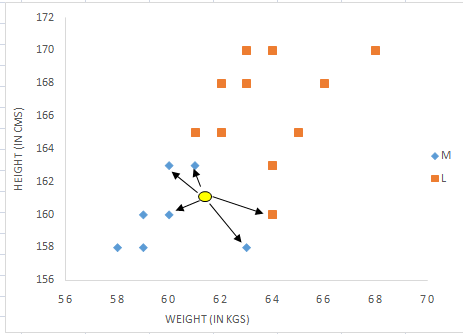

## k-nearest neighbor classifier

- Completely different way of approaching the problem
- Idea: We want to predict \(y^*\) with charcteristics \(x^*_1, ..., x^*_p\) where \(*\) means testing data
1. Find the \(k\) cases in training data that are “closest” to the new case’s characteristics and use their responses (\(y\)) to predict \(y^*\)
2. Use responses of the “closest” cases to predict \(y^*\) using majority vote (most common response)
- Distance measure: how to find closest cases in a p-dimensional predictor space?
  - if \(x\)’s all quantitative: Euclidean distance
  - \(\sqrt{(x_{i1} - x_{j1})^2 + (x_{i2} - x_{j2})^2 + \cdots + (x_{ip} - x_{jp})^2}\)

## k-nearest neighbor classifier

- *lazy-leaner*
  - no formal model
  - no pre-processing of the training data (just need training data to predict test responses)
- Cons:
  - computationally intensive
  - accuracy depends on geometry of predictor space
  - how many neighbors \(k\) to pick?
    - what happens when \(k=1\)? \(k=n\)?
    - smaller \(k\): more overfitting (higher variance)
    - larger \(k\): less overfitting but more bias

## Loans k-nn example

- Let’s analyize Loans data with training data = 80% split, test data = 20%
  - what will the “X”’s be classified?

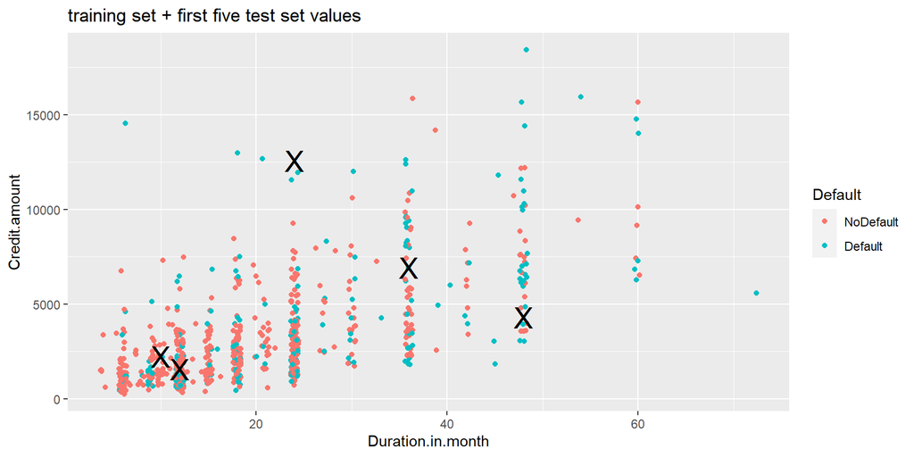

## Loans k-nn example

- R package `class`:
  - `knn(train=, test=, cl=, k=)`
  - `train` and `test` are quantitative **predictor** data frames.
  - `cl` are the training set responses

```r
> loans_knn <- knn(train, test, cl= loans$Default[train_index], k=10)
```

- For the 80%/20% split:
  - using \(k=10\) gives accuracy of 64% and recall of 15%

## Loans k-nn example

- `knn.cv(train=, cl=, k=)` does LOOCV for the `train` data
  - `cl` are the training set responses
- for each row, use `n-1` other rows to find knn group and predict a response

```r
> loans_knn.cv <- knn.cv(loans[,c("Credit.amount","Duration.in.month")],
+                        cl= loans$Default, k=10)
> test <- data_frame(y=loans$Default,prediction = loans_knn.cv)
> test %>%  summarize(accuracy = mean(prediction == y),
+                    precision = sum(prediction == "Default" & y == "Default")/sum(prediction == "Default"),
+                    recall = sum(prediction == "Default" & y == "Default")/sum(y == "Default"),
+                    )
# A tibble: 1 × 3
  accuracy precision recall
     <dbl>     <dbl>  <dbl>
1    0.691     0.460  0.173
```

## Loans k-nn example

- CV rates for a range of k values

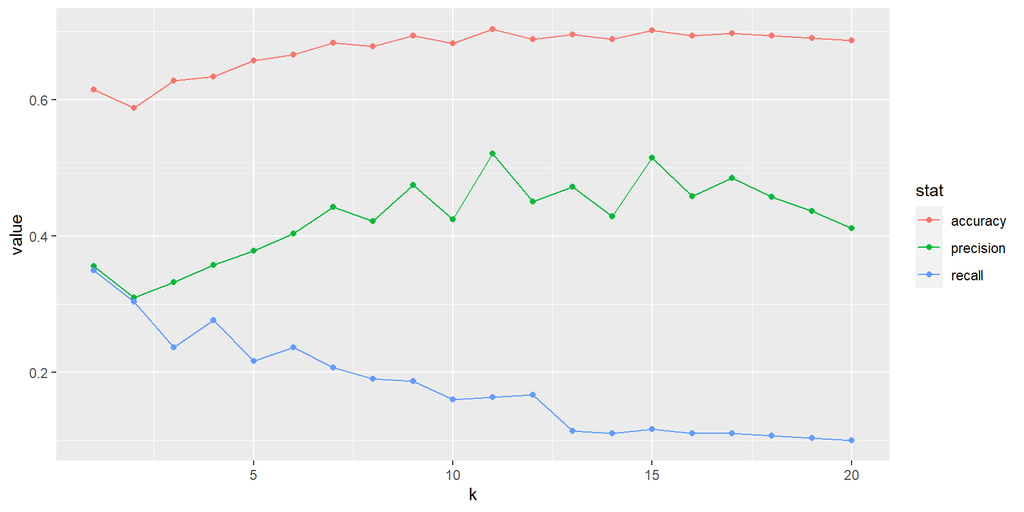

## k-nearest neighbor classifier

- accuracy depends on geometry of predictor space
  - depends *highly* upon the scale of your predictors!
  - predictors with larger variation will have larger influence on which cases are “nearest” neighbors

## Simple example:

- Which of the training cases is closest to the test case?

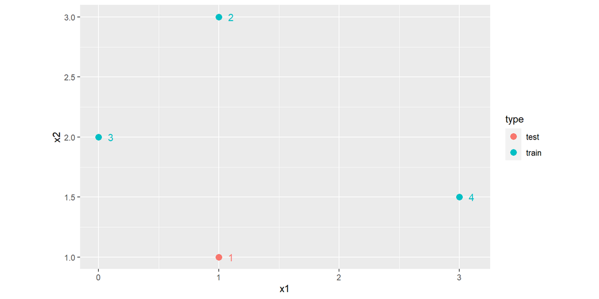

## Simple example:

- Can use the function `dist` to compute the Euclidean distance in \(R^p\) between cases in a data set with p predictors
- For \(R^2\), distance is \(\sqrt{(x-x_0)^2+(y-y_0)^2}\)

```r
> d<- dist(x_df[,1:2])
> x_df <- x_df %>% mutate(dist.from.1 = as.matrix(d)[,1])
> x_df
# A tibble: 4 × 4
     x1    x2 type  dist.from.1
  <dbl> <dbl> <chr>       <dbl>
1     1   1   test         0
2     1   3   train        2
3     0   2   train        1.41
4     3   1.5 train        2.06
```

- As the plot suggests, case 3 is closest to case 1

## Simple example II:

- Now consider this second set of data. How does it differ from first example?
- Which case is closest?

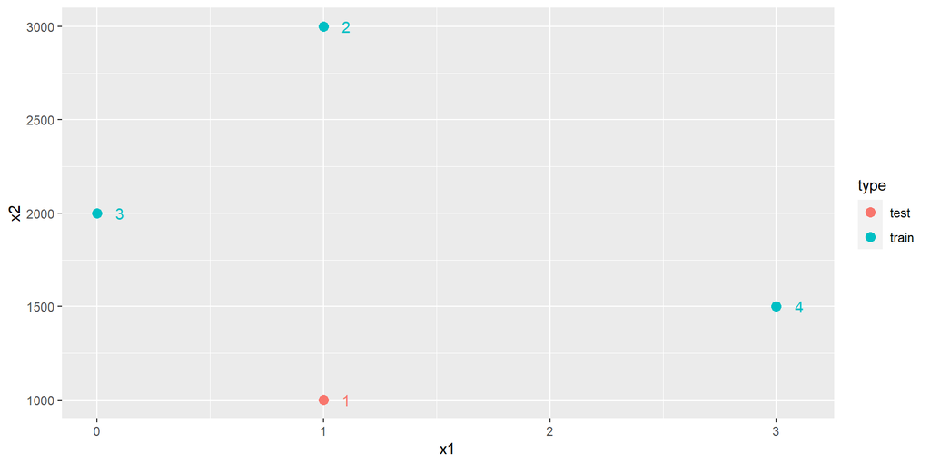

## Simple example II:

- Which training case is closest to 1?

```r
> d<- dist(x_df2[,1:2])
> x_df2 <- x_df2 %>% mutate(dist.from.1 = as.matrix(d)[,1])
> x_df2
# A tibble: 4 × 4
     x1    x2 type  dist.from.1
  <dbl> <dbl> <chr>       <dbl>
1     1  1000 test           0
2     1  3000 train       2000
3     0  2000 train       1000.
4     3  1500 train        500.
```

- Now case 4 is by far the closest!

## Simple example II:

- More obvious that 4 is closest if we use fixed axis ratio
- `x1` becomes meaningless and only `x2` distance matters

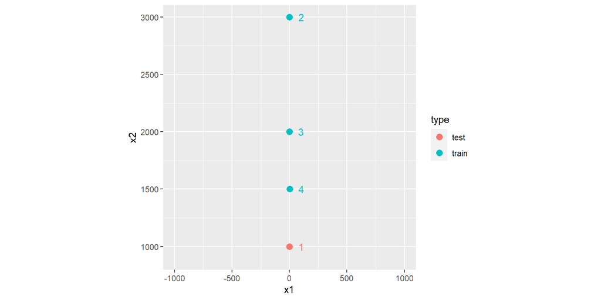

## Conclusion

- the Euclidean distance is a function of variable scale
  - Just plotting the data is misleading because axis scales may be diffrent
- Methods relying on distance can be sensitive (i.e. not invariant) to the scale of the predictors
  - changing `x2` from kilometers (`x_df`) to meters (`x_df2`) changes the case that is closest to test case 1
  - The variables with larger scale will get more weight when computing distance
- With k-nn:
  - should `scale` (subtract `mean` divide by `sd`) predictors if they vary greatly in scale/variation
- Other classifiers (e.g trees, logistic regression) are invariant to linear transformations of predictors (e.g. changing from km to meters won’t change predictions)

## Loans k-nn example

- Do `Credit.amount` and `Duration.in.month` differ by scale?

```r
> loans <- loans %>% mutate(Default = recode_factor(Good.Loan, GoodLoan = "NoDefault",BadLoan = "Default" ),
+          Credit.amount.stan = scale(Credit.amount)[,1], Duration.in.month.stan = scale(Duration.in.month)[,1])
> loans %>% select(Credit.amount, Duration.in.month, Credit.amount.stan, Duration.in.month.stan) %>% summary
 Credit.amount   Duration.in.month Credit.amount.stan Duration.in.month.stan
 Min.   :  250   Min.   : 4.0      Min.   :-1.0703    Min.   :-1.4017
 1st Qu.: 1366   1st Qu.:12.0      1st Qu.:-0.6751    1st Qu.:-0.7383
 Median : 2320   Median :18.0      Median :-0.3372    Median :-0.2407
 Mean   : 3271   Mean   :20.9      Mean   : 0.0000    Mean   : 0.0000
 3rd Qu.: 3972   3rd Qu.:24.0      3rd Qu.: 0.2483    3rd Qu.: 0.2568
 Max.   :18424   Max.   :72.0      Max.   : 5.3681    Max.   : 4.2373
```

## Loans k-nn example

- The scaled version has better recall

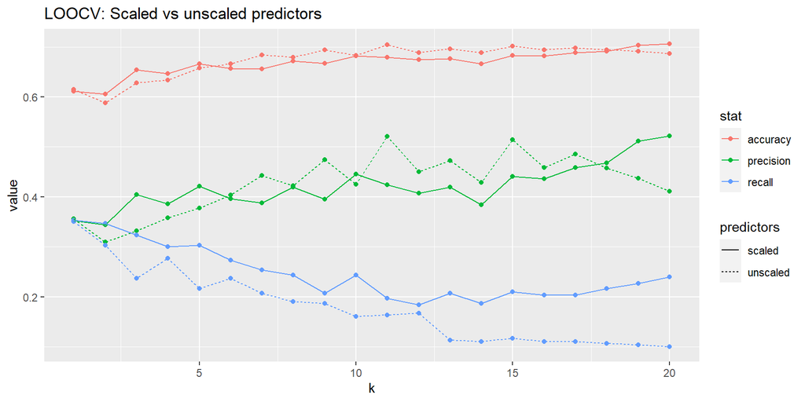

## Classifiers conclusions

- Bootstrap methods for trees helps reduce over-fitting
- Knn offers a much more flexible approach
- When to use each method?
  - logistic and tree methods: good when class boundaries are linear
    - logistic can include higher order polynomials if non-linear
    - knn does worse: too much variance (overfit)
  - knn good when boundaries between classes are not linear
    - flexibility pays off
    - use cv to help assess k choice

## Classifiers conclusions

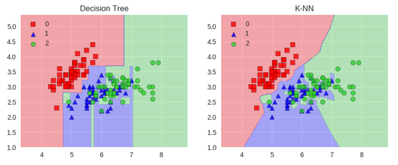

- Trees cut into rectangles, knn is more flexible